# week5-lab

Computational Finance

Copyright

```python
import numpy as np
import pandas as pd
import matplotlib.pyplot as plt
from scipy.optimize import minimize

import warnings
warnings.filterwarnings('ignore')
```

```python
from scipy.stats import norm
def blackscholes(S0, K, T, r, sigma):
    """
    Price of a European call in the Black-Scholes model.
    """
    d1 = (np.log(S0)-np.log(K)+(r+sigma**2/2)*T)/(sigma*np.sqrt(T))
    d2 = d1-sigma*np.sqrt(T)
    return S0*norm.cdf(d1)-np.exp(-r*T)*K*norm.cdf(d2)
```

# Outline

- General feedback assignment 1
- Answers exercise week 4
- Risk-Neutral Density

A European **call option** is a contract that gives the right to the buyer (owner of an option) to buy an agreed quantity of the underlying from the seller at a certain agreed time for a certain strike price.

A payoff **at** the expiration time $T$ is $$\mbox{Payoff}_{call} = C_T(S_T) = \max(S_T-K, 0) $$

The risk-neutral pricing formula gives as the today's price of this contract:

\begin{align*} C_0=e^{-r T}\mathbb{E}^\mathbb{Q}[C_T] &= e^{-r T}\mathbb{E}^\mathbb{Q}[max(S_T-K, 0)]\\ &=e^{-r T} \int_0^\infty max(S_T-K, 0) q(S_T) dS_T\\ &=e^{-r T} \int_K^\infty (S_T-K) q(S_T) dS_T \end{align*}

where $q(S_T)$ is the *risk-neutral density (RND)* of a future stock price $S_T$.

Differentiating the price of the call option with respect to $K$ we get

\begin{align*} C'_K(K) := \frac{\partial C(K)}{\partial K} &= -e^{-rT} (S_T - K)q(S_T)|_{S_T=K} + e^{-rT} \int_K^\infty - q(S_T) d S_T\\ &= -e^{-rT} \int_K^\infty q(S_T) d S_T\\ & = -e^{-rT} (1 - Q_S(K))= -e^{-rT} \overline{Q}_S(K) \end{align*}

where $Q_S(K)$ is the $\mathbb{Q}$-cdf and $\overline{Q}_S(K)$ is corresponding survival function.

Differentiating with respect to $K$ a second time gives \begin{align*} C''_K(K) := \frac{\partial^2 C(K)}{\partial^2 K} = e^{-rT} q(S_T)|_{S_T=K} = e^{-rT} q(K) \end{align*}

Therefore, the RND is given by the second derivative of the call option: \begin{align} q(x) = e^{rT} \frac{\partial^2 C(K)}{\partial^2 K} \Bigg\rvert_{K=x} = e^{rT} C''_K(x). \end{align}

This result known from Breeden and Litzenberger (1978). Similar results can be obtained for the put options.

- Risk-neutral density (RND) is the building block for derivative pricing.
- RND can be used to price any other derivatives
- RND reflects investor's perception about the market movements

We can extract the RND from the option prices:

$$q(x) = e^{rT} C''_K(x)$$

- the second derivative is not known for every $x$
- we can use discrete approximation using available strike prices
- the discrete approximation largely depends on quality of data
- there are several constraints that we can guarantee to be satisfied

The approximate density given a finite set of options is

$$q(K_n) = e^{rT} \frac{C_{n+1} - 2C_{n} + C_{n-1}}{(\Delta K)^2}$$

for any $1 < n< N$

- This approximation is not smooth and not robust to observation errors
- Evaluated only at a finite set of points
- The RND tails outside the range of observed strikes needs to be somehow extrapolated

Parametric modeling estimation of the RND:

- impose a parametric assumption on the return process, or on the density without specifying price dynamics
- can possibly misprice even market-observed options
- for instance, binomial tree produces a binomial distribution as the RND.

Nonparametric modeling estimation of the RND:

- smooth and fill in the option price curve as a function of strike prices
- interpolate between the market-observed prices
- matches market pricing, but does not work well when option prices are too noisy or too sparse

# Example

- We consider options on S&P 500 in two days: 15.10.2019 and 24.03.2020
- Time-to-maturity is 7 days in both cases
- Data are already cleaned and pre-processed
- BSIVs are already calculated

```python
df1 = pd.read_csv("../data/spx-2019-10-15-7d.csv")
df2 = pd.read_csv("../data/spx-2020-03-24-7d.csv")
```

```python
df1
```

|  | quote_date | root | expiration | strike | option_type | trade_volume | tenor | tenor_days | mid_quote_1545 | Rf | forward | k | bsiv |
| --- | --- | --- | --- | --- | --- | --- | --- | --- | --- | --- | --- | --- | --- |
| 0 | 15/10/2019 | SPXW | 21/10/2019 | 2560 | P | 500 | 0.019207 | 7 | 0.075 | 1.8532 | 2997.699181 | 0.853988 | 0.389733 |
| 1 | 15/10/2019 | SPXW | 21/10/2019 | 2600 | P | 0 | 0.019207 | 7 | 0.075 | 1.8532 | 2997.699181 | 0.867332 | 0.354504 |
| 2 | 15/10/2019 | SPXW | 21/10/2019 | 2640 | P | 0 | 0.019207 | 7 | 0.075 | 1.8532 | 2997.699181 | 0.880675 | 0.319568 |
| 3 | 15/10/2019 | SPXW | 21/10/2019 | 2675 | P | 24 | 0.019207 | 7 | 0.100 | 1.8532 | 2997.699181 | 0.892351 | 0.297302 |
| 4 | 15/10/2019 | SPXW | 21/10/2019 | 2680 | P | 0 | 0.019207 | 7 | 0.100 | 1.8532 | 2997.699181 | 0.894019 | 0.292875 |
| ... | ... | ... | ... | ... | ... | ... | ... | ... | ... | ... | ... | ... | ... |
| 87 | 15/10/2019 | SPXW | 21/10/2019 | 3095 | C | 0 | 0.019207 | 7 | 0.150 | 1.8532 | 2997.699181 | 1.032458 | 0.099803 |
| 88 | 15/10/2019 | SPXW | 21/10/2019 | 3100 | C | 2 | 0.019207 | 7 | 0.125 | 1.8532 | 2997.699181 | 1.034126 | 0.101826 |
| 89 | 15/10/2019 | SPXW | 21/10/2019 | 3105 | C | 16 | 0.019207 | 7 | 0.125 | 1.8532 | 2997.699181 | 1.035794 | 0.106093 |
| 90 | 15/10/2019 | SPXW | 21/10/2019 | 3110 | C | 53 | 0.019207 | 7 | 0.125 | 1.8532 | 2997.699181 | 1.037462 | 0.110335 |
| 91 | 15/10/2019 | SPXW | 21/10/2019 | 3115 | C | 64 | 0.019207 | 7 | 0.100 | 1.8532 | 2997.699181 | 1.039130 | 0.111578 |

92 rows × 13 columns

- Data have only out-of-the-money options, that is, put options if $K < S$ and call options of $K > S$.
- Calculate Call equivalents for Puts using Put-Call parity

```python
df1["call"] = (df1.option_type=="P")*(df1.mid_quote_1545 + np.exp(-df1.Rf/100*df1.tenor)*(df1.forward - df1.strike)) + (df1.option_type=="C")*df1.mid_quote_1545
df2["call"] = (df2.option_type=="P")*(df2.mid_quote_1545 + np.exp(-df2.Rf/100*df2.tenor)*(df2.forward - df2.strike)) + (df2.option_type=="C")*df2.mid_quote_1545
df1
```

|  | quote_date | root | expiration | strike | option_type | trade_volume | tenor | tenor_days | mid_quote_1545 | Rf | forward | k | bsiv | call |
| --- | --- | --- | --- | --- | --- | --- | --- | --- | --- | --- | --- | --- | --- | --- |
| 0 | 15/10/2019 | SPXW | 21/10/2019 | 2560 | P | 500 | 0.019207 | 7 | 0.075 | 1.8532 | 2997.699181 | 0.853988 | 0.389733 | 437.618415 |
| 1 | 15/10/2019 | SPXW | 21/10/2019 | 2600 | P | 0 | 0.019207 | 7 | 0.075 | 1.8532 | 2997.699181 | 0.867332 | 0.354504 | 397.632650 |
| 2 | 15/10/2019 | SPXW | 21/10/2019 | 2640 | P | 0 | 0.019207 | 7 | 0.075 | 1.8532 | 2997.699181 | 0.880675 | 0.319568 | 357.646885 |
| 3 | 15/10/2019 | SPXW | 21/10/2019 | 2675 | P | 24 | 0.019207 | 7 | 0.100 | 1.8532 | 2997.699181 | 0.892351 | 0.297302 | 322.684341 |
| 4 | 15/10/2019 | SPXW | 21/10/2019 | 2680 | P | 0 | 0.019207 | 7 | 0.100 | 1.8532 | 2997.699181 | 0.894019 | 0.292875 | 317.686120 |
| ... | ... | ... | ... | ... | ... | ... | ... | ... | ... | ... | ... | ... | ... | ... |
| 87 | 15/10/2019 | SPXW | 21/10/2019 | 3095 | C | 0 | 0.019207 | 7 | 0.150 | 1.8532 | 2997.699181 | 1.032458 | 0.099803 | 0.150000 |
| 88 | 15/10/2019 | SPXW | 21/10/2019 | 3100 | C | 2 | 0.019207 | 7 | 0.125 | 1.8532 | 2997.699181 | 1.034126 | 0.101826 | 0.125000 |
| 89 | 15/10/2019 | SPXW | 21/10/2019 | 3105 | C | 16 | 0.019207 | 7 | 0.125 | 1.8532 | 2997.699181 | 1.035794 | 0.106093 | 0.125000 |
| 90 | 15/10/2019 | SPXW | 21/10/2019 | 3110 | C | 53 | 0.019207 | 7 | 0.125 | 1.8532 | 2997.699181 | 1.037462 | 0.110335 | 0.125000 |
| 91 | 15/10/2019 | SPXW | 21/10/2019 | 3115 | C | 64 | 0.019207 | 7 | 0.100 | 1.8532 | 2997.699181 | 1.039130 | 0.111578 | 0.100000 |

92 rows × 14 columns

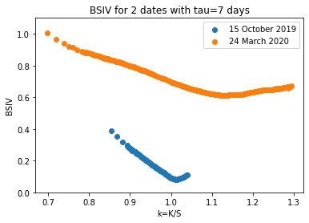

```python
plt.scatter(df1.k, df1.bsiv);
plt.scatter(df2.k, df2.bsiv);
plt.ylim((0,1.1))
plt.legend(["15 October 2019", "24 March 2020"]);
plt.ylabel("BSIV"); plt.xlabel("k=K/S")
plt.title("BSIV for 2 dates with tau=7 days");
```

Define a function to calculate the RND given call prices

```python
def rnd(C, K):
    " RND approximation"
    n = len(K)
    q = np.zeros(n-1)
    for i in range(1,n-1):
        q[i] = (C[i-1] + C[i+1] - 2*C[i])/((K[i] - K[i-1])**2)

    return q
```

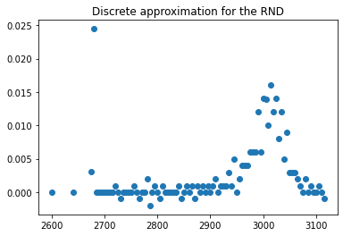

```python
q1_discrete = rnd(df1.call.values, df1.strike.values)
plt.scatter(df1.strike[1:], q1_discrete);
plt.title("Discrete approximation for the RND");
```

# SVI fit

- To approximate and smooth out data, we will fit a parametric form on the BSIV.
- We will use an industry-standard SVI (stochastic volatility inspired) model
- Simple parametric form, few parameters, easy to fit and it guarantees arbitrage-free conditions

SVI parametrization of implied total variance $w(x,\tau) = \sigma_{BS}^2(x)\tau$ as a function of log-moneyness $x = \log k = \log(K/S)$:

$$ w(x,\tau;\theta) = a + b\left(\rho(x-m) + \sqrt{(x-m)^2 + \sigma^2} \right) $$

with a parameter set $\theta = \{a,b,\rho,m,\sigma\}$ such that:$a \in \mathbb{R}, b \geq 0, |\rho| < 1, m \in \mathbb{R}, \sigma > 0$ and $a + b\sigma \sqrt{1-\rho^2} \geq 0$

where $\sigma_{BS}^2(x_n)$ is the market-observed BSIV data

```python
def svi(param, logk):
    """
    Row parametrization of SVI
    :param param: vector of parameters [a, b, rho, m, s]
    :param logk: log(K/F)
    :return: ivar: implied variance
    """
    a, b, rho, m, s = param
    ivar = a + b * (rho * (logk - m) + np.sqrt((logk - m)**2 + s ** 2))

    return ivar

def svi_calibration(param, BSIV, logk, tau):
    """ Row SVI calibration based on the market-observed bsiv data """

    fn = np.sum(((BSIV ** 2)*tau - svi(param, logk)) ** 2)

    return fn
```

```python
bnds = ((None, None), (0, None), (-1,1), (None,None), (0,None))
cons = ({'type': 'ineq', 'fun': lambda x:  x[0] + x[1]*x[4]*np.sqrt(1-x[2]**2)})

res1_svi = minimize(svi_calibration, np.array([-0.024, 0.09, 0.45, 0.16, 0.3]),  args=(df1.bsiv, np.log(df1.k), df1.tenor[0]),
                   method='SLSQP', bounds = bnds, constraints=cons,
                   tol=1e-8, options={'maxiter': 50000})

res1_svi
```

```
     fun: 7.660570758633335e-08
     jac: array([ 2.49798028e-05,  8.46488246e-06, -1.33083040e-06,  1.55728509e-06,
        5.72087881e-07])
 message: 'Optimization terminated successfully'
    nfev: 39
     nit: 6
    njev: 6
  status: 0
 success: True
       x: array([-0.02444438,  0.09258812,  0.44771566,  0.16435463,  0.29710923])
```

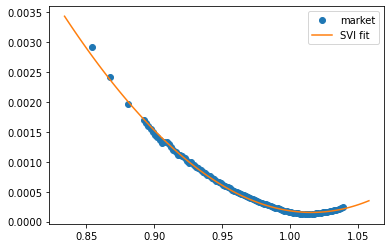

```python
k1_range = np.arange(df1.k.min()-0.02, df1.k.max()+0.02, 0.002)

plt.plot(df1.k, df1.bsiv**2*df1.tenor[0], 'o', k1_range, svi(res1_svi.x, np.log(k1_range)), '-');
plt.legend(["market", "SVI fit"]);
```

```python
res2_svi = minimize(svi_calibration, np.array([0.006, 0.018, -0.32, 0.1, 0.03]),  args=(df2.bsiv, np.log(df2.k), df2.tenor[0]),
                   method='SLSQP', bounds = bnds, constraints=cons,
                   tol=1e-8, options={'maxiter': 50000})

res2_svi
```

```
     fun: 4.274661538582675e-06
     jac: array([-4.95941364e-05, -6.28270075e-05,  5.79664959e-06, -3.33817046e-05,
       -9.75707900e-06])
 message: 'Optimization terminated successfully'
    nfev: 41
     nit: 6
    njev: 6
  status: 0
 success: True
       x: array([ 0.00659581,  0.0190757 , -0.32090926,  0.10981712,  0.03106327])
```

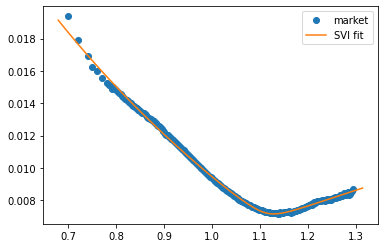

```python
k2_range = np.arange(df2.k.min()-0.02, df2.k.max()+0.02, 0.002)

plt.plot(df2.k, df2.bsiv**2*df2.tenor[0], 'o', k2_range, svi(res2_svi.x, np.log(k2_range)), '-');
plt.legend(["market", "SVI fit"]);
```

```python
IV1_svi = np.sqrt(svi(res1_svi.x, np.log(k1_range))/df1.tenor[0])  # tenor = time-to-maturity
IV2_svi = np.sqrt(svi(res2_svi.x, np.log(k2_range))/df2.tenor[0])

call1_svi = blackscholes(np.exp(-df1.Rf.values[0]/100*df1.tenor.values[0])*df1.forward.values[0], df1.forward.values[0]*k1_range, df1.tenor.values[0], df1.Rf.values[0]/100, IV1_svi)
call2_svi = blackscholes(np.exp(-df2.Rf.values[0]/100*df2.tenor.values[0])*df2.forward.values[0], df2.forward.values[0]*k2_range, df2.tenor.values[0], df2.Rf.values[0]/100, IV2_svi)
```

```python
q1 = rnd(call1_svi, df1.forward.values[0]*k1_range)
q2 = rnd(call2_svi, df2.forward.values[0]*k2_range)
```

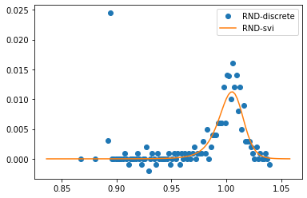

```python
plt.plot(df1.strike[1:]/df1.forward[0], q1_discrete, 'o', k1_range[1:], q1, '-');
plt.legend(["RND-discrete", "RND-svi"]);
```

Now compare two RNDs:

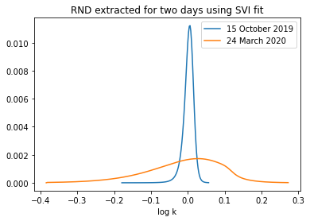

```python
plt.plot(np.log(k1_range[1:]), q1);
plt.plot(np.log(k2_range[1:]), q2);
plt.legend(["15 October 2019", "24 March 2020"]);
plt.xlabel("log k")
plt.title("RND extracted for two days using SVI fit");
```

[figure not shown]

- 21 February, just before the virus outbreak reached Europe in full force
- A week later (28 February)
- 20 March, after significant policy stimulus had been announced in the euro area andthe United States
- Source: [ECB Economic Bulletin, Issue 4/2020.](https://www.ecb.europa.eu/pub/economic-bulletin/focus/2020/html/ecb.ebbox202004_02~26672a3808.en.html)